# Assessment 1

Mitchell Wake

2023-11-07

# Research Question

Global energy demand has been growing consistently as populations increase and societies get wealthier (Ritchie, Rosado, and Roser 2020). This report will examine the historical trends in population numbers alongside per capita energy consumption of the ten nations with the highest energy consumption in 2021.

# Data Set Introduction

The dataset used in this report has been extracted and cleaned from [Our World in Data Energy Dataset](https://ourworldindata.org/energy). It contains data for 10 Countries Energy Consumption in kilowatt hours (kWh) per Capita and population numbers for every year from 1985 to 2022. The cleaned data can be accessed and downloaded locally from here.

The data set contains the following variables.

```r
var_names <- read.csv('data/variable_names.csv')
kable(var_names) %>% kable_classic(full_width = FALSE, position = "left")
```

| Variable_Names | Description |
| --- | --- |
| country | Geographic location |
| year | Year of observation |
| population | Countries Population |
| energy_per_capita | Primary energy consumption per capita, measured in kilowatt-hours |

# Data Set Description

The number of variables in the dataset is 4 and the number of observations is 380.

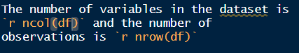

Figure 1: r inline code

```r
knitr::include_graphics(path="image/screenshot.png")
```

The below table shows the types of variables and the first two observations for each variable.

```r
str(head(df,2))
```

```
## 'data.frame':    2 obs. of  4 variables:
##  $ country          : chr  "Brazil" "Brazil"
##  $ year             : int  1985 1986
##  $ population       : int  136783184 139643360
##  $ energy_per_capita: num  10028 10361
```

# Data Summary

To examine the historical trends of population and energy consumption we have calculated the average energy consumption per capita and average population size for each country between 1985 to 2022. Additionally we have calculated the average growth rates for both variables over this time period. See table 1.

```r
df %>% group_by(country) %>% arrange(year) %>%
  summarise('Avg kWh/Capita' = paste0(format(round(mean(energy_per_capita), 2),big.mark=",")),
            'Avg kWh/Capita Growth' = paste0(round(((last(energy_per_capita) / first(energy_per_capita))^(1 / (n() - 1)) - 1) * 100, 2), "%"),
            'Avg Population (Millions)' = paste0(round(mean(population / 1e6), 2), "M"),
            'Avg Population Growth' = paste0(round(((last(population) / first(population))^(1 / (n() - 1)) - 1) * 100, 2), "%")) %>%
  head(10) %>%
  kable(caption = "Countries Average Energy Consumption (kWh) by Capita and Population (Millions) from 1985 to 2022") %>%
  kable_classic(full_width = FALSE, position = "left")
```

Table 1: Countries Average Energy Consumption (kWh) by Capita and Population (Millions) from 1985 to 2022

| country | Avg kWh/Capita | Avg kWh/Capita Growth | Avg Population (Millions) | Avg Population Growth |
| --- | --- | --- | --- | --- |
| Brazil | 13,816.85 | 1.48% | 180.91M | 1.23% |
| Canada | 112,675.7 | -0.21% | 31.98M | 1.08% |
| China | 15,872.13 | 4.64% | 1282.89M | 0.8% |
| France | 47,423.24 | -0.52% | 60.12M | 0.43% |
| Germany | 48,617.3 | -0.8% | 81.13M | 0.19% |
| India | 4,227.97 | 3.46% | 1116.52M | 1.63% |
| Japan | 44,105.66 | 0.21% | 125.93M | 0.06% |
| Russia | 56,748.59 | -0.5% | 145.62M | 0.03% |
| South Korea | 48,619.63 | 4.15% | 47.47M | 0.62% |
| United States | 86,417.82 | -0.23% | 290.39M | 0.99% |

The second table 2 shows the same metrics except as an aggregate of the ten counrties.

```r
df %>%
summarise('Avg kWh/Capita' = paste0(format(round(mean(energy_per_capita), 2),big.mark=",")),
            'Avg kWh/Capita Growth' = paste0(round(((last(energy_per_capita) / first(energy_per_capita))^(1 / (n() - 1)) - 1) * 100, 2), "%"),
            'Avg Population (Millions)' = paste0(round(mean(population / 1e6), 2), "M"),
            'Avg Population Growth' = paste0(round(((last(population) / first(population))^(1 / (n() - 1)) - 1) * 100, 2), "%")) %>%
  kable(caption="All 10 Countries Averages and Growth Rates of Energy Consumption (kWh) by Capita and Population (Millions)") %>%
  kable_classic(full_width = FALSE, position = "left")
```

Table 2: All 10 Countries Averages and Growth Rates of Energy Consumption (kWh) by Capita and Population (Millions)

| Avg kWh/Capita | Avg kWh/Capita Growth | Avg Population (Millions) | Avg Population Growth |
| --- | --- | --- | --- |
| 47,852.49 | 0.55% | 336.3M | 0.24% |

**Observations**

We observe from the data summary that all 10 countries have **positive** population growth rates over the time period, however they do not all have positive growth in energy consumption per capita. Five countries; Canada, France, Germany, Russia and the United States have had **negative** average growth in energy consumption per capita. As an aggregate energy consumption and population numbers increased **positively** over the time period.